## Elements Of Data Science - S2022

# Week 5: Intro to Machine Learning Models

### 2/15/2022

# TODOs

- Readings:
  - Recommended: https://scikit-learn.org/stable/supervised_learning.html
  - **Read** PDSH Chap 5 In Depth: Linear Regression
  - **Read** PDSH Chap 5 In Depth: Support Vector Machines
  - **Read** PDSH Chap 5 In Depth: Decision Trees and Random Forests
  - **Read** Chapter 3 from HOML
  - **Read** Chapter 4 from HOML
- Quiz 5, Due Mon Feb 21st, 11:59pm
- HW1 Due Fri Feb 18th, 11:59pm ET

# Today

- Intro to Machine Learning Models
- Various types of ML
- Linear models
- Next week:
  - One Vs. Rest For Multiclass/Multilabel Classification
  - Distance Based: kNN
  - Tree Based: Decision Tree
  - Ensembles: Bagging, Boosting, Stacking

# Questions?

# Environment Setup

```python
import numpy as np
import pandas as pd
import matplotlib.pyplot as plt
import seaborn as sns

sns.set_style('darkgrid')

%matplotlib inline
```

# Modeling and ML

- What is a Model?
  - Specification of a mathematical (or probabilistic) relationship between different variables.
- What is Machine Learning?
  - Creating and using models that are learned from data.

# Questions for Models

```python
df_wine = pd.read_csv('../data/wine_dataset.csv',usecols=['alcohol','ash','proline','hue','class'])
df_wine.sample(4,random_state=1)
```

|  | alcohol | ash | hue | proline | class |
| --- | --- | --- | --- | --- | --- |
| 161 | 13.69 | 2.54 | 0.96 | 680.0 | 2 |
| 117 | 12.42 | 2.19 | 1.06 | 345.0 | 1 |
| 19 | 13.64 | 2.56 | 0.96 | 845.0 | 0 |
| 69 | 12.21 | 1.75 | 1.28 | 718.0 | 1 |

- Can we predict target/label "class" from the other columns? **(Classification)**
- Can we predict target/label "hue" from the other columns? **(Regression)**
- What are the important features when predicting "hue"? **(Feature Selection)**
- Can a model tell us about how the features and target/label interact? **(Interpretation)**
- Do the observations group together in feature space? **(Clustering)**

# Data Vocabulary for ML

```python
df_wine.sample(5,random_state=1)
```

|  | alcohol | ash | hue | proline | class |
| --- | --- | --- | --- | --- | --- |
| 161 | 13.69 | 2.54 | 0.96 | 680.0 | 2 |
| 117 | 12.42 | 2.19 | 1.06 | 345.0 | 1 |
| 19 | 13.64 | 2.56 | 0.96 | 845.0 | 0 |
| 69 | 12.21 | 1.75 | 1.28 | 718.0 | 1 |
| 53 | 13.77 | 2.68 | 1.13 | 1375.0 | 0 |

- $X$, features, attributes, independent/exogenous/explanatory variables
  - Ex: alcohol, trip_distance, company_industry
- $y$, target, label, outcome, dependent/endogenous/response variables
  - Ex: class, hue, tip_amount, stock_price
- $f(X)\rightarrow y$, Model that maps features $X$ to target $y$

# Variations of ML Tasks

- **Supervised** vs **Unsupervised**
  - is there a target/label?
- **Regression** vs **Classification**
  - is the target numeric or categorical?
- **Prediction** vs **Interpretation**
  - generate predictions or understand interactions?
- Model Families
  - Linear, Tree, Distance, Probability, Neural Net, Ensemble, ...

# Supervised vs Unsupervised vs Reinforcement Learning

Is there a target, $y$?

- Yes:
  - **Supervised Learning:** Data consists of $(X,y)$ pairs
  - Uses: Classification, Regression
  - Ex: What is the relationship between length of ride and tip amount?
- No:
  - **Unsupervised Learning:** Data consists only of $(X)$
  - Uses: Clustering, Topic Modeling, etc.
  - Ex: Are there any clusters in length of ride?
- Eventually:
  - **Reinforcement Learning**
  - After a series of predictions (path) get a reward from a reward function
  - Ex. Poker player

# Other Learning Paradigms

- Do we have a mix of labeled and unlabeled?
  - **Semi-Supervised Learning**
  - Can we use structure of unlabeled data along with labeled?
- Will we continue getting new data?
  - **Online Learning**
  - Is there an oracle (ground truth) we can consult?
  - Can we select which points to make predictions on?

# Supervised Learning: Regression vs Classification

- **Regression** -> predict a numeric value
  - Ex: tip_amount, stock_price, wine_hue
- **Classification** -> predict a discrete class/category
  - Ex: class of wine, face/not face, object labels in image
- Note: convert a regression problem into classification with binning/thresholding

  From PML

# Prediction vs Interpretation

  - Do we care more about: the accuracy when generating predictions?
    - Ex: For a given taxi trip, what will the tip size likely be?
    - Ex: For a given loan, will there be a default?
  - Do we care more about: understanding how $X$ relates to $y$?
    - Ex: What happens to tip size as taxi trip length increases?
    - Ex: What is the relationship between debt and loan default?

# Model Families for Supervised Learning

  - Linear
    - Simple/Multiple Linear Regression
    - Logistic Regression (for Classification)
    - Support Vector Machines
    - Perceptron
  - Tree Based
    - Decision Tree
  - Distance Based
    - K-Nearest Neighbor

# Model Families for Supervised Learning Continued

  - Probability
    - Naive Bayes
    - Bayes Net
  - Ensemble
    - Random Forest
    - Gradient Boosted Trees
    - Stacking
  - Network
    - Multi-layer Perceptron
    - Deep Neural-Networks
    - Convolutional Neural Nets
    - Recurrant Neural Nets

# Example: Regression with a Linear Model

  What is the relationship between 'proline' (an amino-acid) and 'alcohol' in wine?

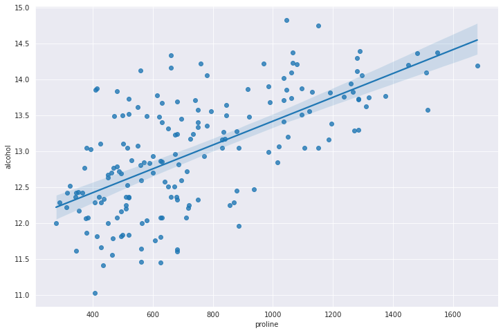

  ```python
  fig,ax = plt.subplots(1,1,figsize=(12,8))
  sns.regplot(x='proline', y='alcohol', data=df_wine);
  ```

# Aside: Correlation

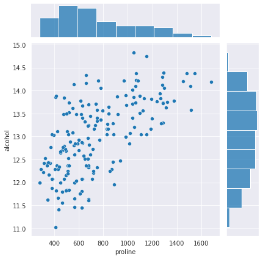

  ```python
  sns.jointplot(x='proline',y='alcohol',data=df_wine);
  ```

# Obligitory Correlation vs. Causation

[figure not shown]

  https://imgs.xkcd.com/comics/correlation.png
  - Correlation does not mean causation!
  - Causal Inference
    - controlled experiment
    - control for confounding variables

# Spurious Correlation

  - Also, look hard enough and you'll find correlation.
    - See [spurious correlations](https://www.tylervigen.com/spurious-correlations) for examples

[figure not shown]

# Aside: Correlation

  - Could calculate Pearson Correlation Coefficient
  - Assumes normally distributed data! (which is not true here)
    - On the Effects of Non-Normality on the Distribution of the Sample Product-Moment Correlation Coefficient](https://www.jstor.org/stable/2346598?seq=1#page_scan_tab_contents)

  ```python
  from scipy.stats import pearsonr
  r,p = pearsonr(df_wine.proline,df_wine.alcohol)
  print(f'r: {r:.2f}, p: {p:.2f}')
  ```

  ```
  r: 0.64, p: 0.00
  ```

  - We know that as proline goes up alcohol goes up, but by how much?

# Python Modeling Libraries

  Prediction - scikit-learn

  Interpretation - scikit-learn and statsmodels

  Additional Tools - mlxtend

# Aside: MLxtend and conda-forge

  - **MLxtend:** (machine learning extensions) is a Python library of useful tools for the day-to-day data science tasks.
  - **Conda-Forge:** A community-led collection of recipes, build infrastructure and distributions for the conda package manager.

[figure not shown]

  ```
  # NOTE: just an example, don't need to run, already installed
  $ conda install --name eods-s22 --channel conda-forge mlxtend
  ```

# Simple Linear Regression

  $\Large y = w_1 x + w_0 + \varepsilon_i$
  - **$y$** : dependent/endogenous response, target, label (Ex: `alcohol`)
  - **$x_i$** : independent/exogenous/explanatory feature, attribute (Ex: `proline`)
  - **$w_1$** : coefficient, slope
  - **$w_0$** : bias term, intercept
  - **$\varepsilon_i$** : error, hopefully small, often assumed $\mathcal{N}(0,\varsigma^2)$
  - Want to find values for $w_1$ and $w_0$ that best fit the data.
  - Find a line as close to our observations as possible

# Simple Linear Regression

[figure not shown]

  from PML

# Finding $w_1$ and $w_0$ with Ordinary Least Squares

  - **prediction**: $\hat{y}_i = f(x_i) = w_1 x_i + w_0$
  - **error**: $error(y_i,\hat{y}_i) = y_i - \hat{y}_i$
  - **sum of squared errors**: $\sum_{i=1:n}{\left(y_i - \hat{y}_i\right)^2}$
  - **least squares**: make the sum of squared errors as small as possible
  - **gradient descent**: minimize error by following the gradient wrt $w_1,w_0$
    - can sometimes be optimized in closed form
    - often done iteratively

# Aside: Gradient Descent

  - Want to maximize or minimize something (Ex: squared error)
  - **Gradient** : direction, vector of partial derivatives
    - can get complicated, often estimated
  - **Gradient Descent** : take steps wrt the direction of the gradient
    - **maximize** : in the direction of the gradient
    - **minimize** : in the opposite direction of the gradient
  - **Global Maximum/Minimum** : the single best solution
  - **Local Maximum/Minimum** : the best solution in the neighborhood

# Aside: Gradient Descent Cont.

[figure not shown]

# Simple Regression Using scikit-learn

  ```python
  # import the model from sklearn
  from sklearn.linear_model import LinearRegression
  ```

  ```python
   # instantiate the model and set hyperparameters
  lr = LinearRegression(fit_intercept=True, # by default
                        normalize=False)    # by default
  ```

  ```python
  # fit the model
  lr.fit(X=df_wine.proline.values.reshape(-1, 1), y=df_wine.alcohol);
  ```

  ```python
  # display learned coefficients (trailing underscore indicates learned values)
  print(lr.coef_)
  print(lr.intercept_)
  ```

  ```
  [0.0016595]
  11.761148483143145
  ```

  ```python
  # predict given new values for proline
  X = np.array([1000,2000]).reshape(-1,1)
  lr.predict(X)
  ```

  ```
  array([13.42064866, 15.08014884])
  ```

# Why .reshape(-1,1)?

  scikit-learn models expect the input features to be 2 dimensional

  ```python
  df_wine.proline.values[:5]
  ```

  ```
  array([1065., 1050., 1185., 1480.,  735.])
  ```

  ```python
  df_wine.proline.values.shape
  ```

  ```
  (178,)
  ```

  ```python
  df_wine.proline.values.reshape(-1,1).shape # -1 means "infer from the data"
  ```

  ```
  (178, 1)
  ```

  Alternatives:

  ```python
  df_wine.loc[:,['proline']].shape
  ```

  ```
  (178, 1)
  ```

  ```python
  df_wine[['proline']].shape
  ```

  ```
  (178, 1)
  ```

# Interpreting Coefficients

  ```python
  print(f'w_1 = {lr.coef_[0]:0.3f}, w_0 = {lr.intercept_:0.3f}')
  ```

  ```
  w_1 = 0.002, w_0 = 11.761
  ```

  ```python
  print(f'alchohol = {lr.coef_[0]:0.3f}*proline + {lr.intercept_:0.3f}')
  ```

  ```
  alchohol = 0.002*proline + 11.761
  ```

  - When proline goes up by 1, alcohol goes up by .002
  - When proline is 0, alcohol is 11.761

# Plotting The Model

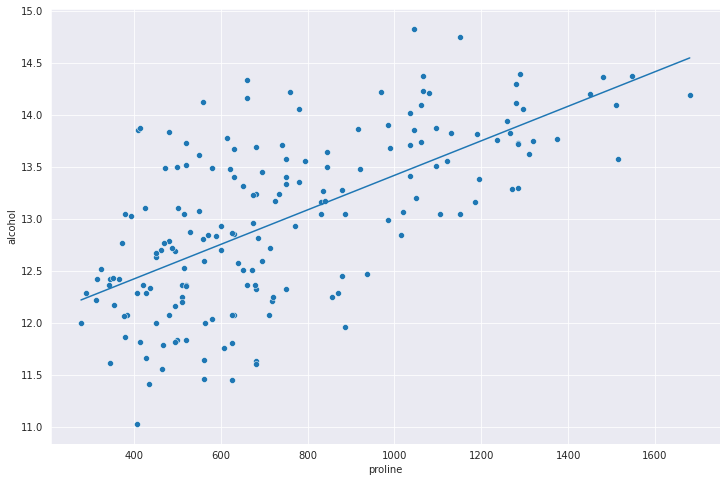

  ```python
  x_predict = [df_wine.proline.min(),df_wine.proline.max()]
  y_hat = lr.predict(np.array(x_predict).reshape(-1,1))

  fig,ax = plt.subplots(1,1,figsize=(12,8))
  ax = sns.scatterplot(x=df_wine.proline,y=df_wine.alcohol);
  ax.plot(x_predict,y_hat);
  ```

# Multiple Linear Regression

  - Including multiple independent variables

  $$ y_i = w_0 + w_1 x_{i1} + w_2 x_{i2} + \ldots + w_m x_{im} + \varepsilon_i $$

  Ex:

  alcohol = w_0 + w_1*proline + w_2*hue

  Objective: Find a *plane* that falls as close to our points as possible

[figure not shown]

# Multiple Linear Regression in scikit-learn

  ```python
  mlr = LinearRegression()
  mlr.fit(df_wine[['proline','hue']],y=df_wine.alcohol);

  for (name,coef) in zip(['proline','hue'],mlr.coef_):
      print(f'{name:10s} : {coef: 0.3f}')
  print(f'{"intercept":10s} : {mlr.intercept_:0.3f}')
  ```

  ```
  proline    :  0.002
  hue        : -0.842
  intercept  : 12.459
  ```

  - If we hold everything else constant, what effect does each variable have?
    - If hue is held constant, a rise of 1 proline -> rise of .002 in alcohol
    - If proline is held constant, a rise of 1 hue -> decrease of .842 in alcohol
  - Can add interaction terms to allow both to move
    - Ex: hue * proline
    - more complicated to interpret

# Multiple Linear Regression in statsmodels

  ```python
  import statsmodels.api as sm

  X = df_wine[['proline','hue']].copy()
  X['const'] = 1 # or use sm.add_constant(X)
  y = df_wine.alcohol
  sm_mlr = sm.OLS(y,X).fit() # Note: X,y passed as parameters to object, not fit
  sm_mlr.summary()
  ```

  OLS Regression Results

  | Dep. Variable: | alcohol | R-squared: | 0.467 |
  | --- | --- | --- | --- |
  | Model: | OLS | Adj. R-squared: | 0.461 |
  | Method: | Least Squares | F-statistic: | 76.79 |
  | Date: | Mon, 11 Oct 2021 | Prob (F-statistic): | 1.15e-24 |
  | Time: | 18:56:48 | Log-Likelihood: | -158.89 |
  | No. Observations: | 178 | AIC: | 323.8 |
  | Df Residuals: | 175 | BIC: | 333.3 |
  | Df Model: | 2 |  |  |
  | Covariance Type: | nonrobust |  |  |

  |  | coef | std err | t | P>\|t\| | [0.025 | 0.975] |
  | --- | --- | --- | --- | --- | --- | --- |
  | proline | 0.0018 | 0.000 | 12.325 | 0.000 | 0.002 | 0.002 |
  | hue | -0.8418 | 0.202 | -4.175 | 0.000 | -1.240 | -0.444 |
  | const | 12.4593 | 0.203 | 61.347 | 0.000 | 12.058 | 12.860 |

  | Omnibus: | 0.751 | Durbin-Watson: | 1.734 |
  | --- | --- | --- | --- |
  | Prob(Omnibus): | 0.687 | Jarque-Bera (JB): | 0.606 |
  | Skew: | 0.142 | Prob(JB): | 0.739 |
  | Kurtosis: | 3.028 | Cond. No. | 4.96e+03 |

  Notes:  
  [1] Standard Errors assume that the covariance matrix of the errors is correctly specified.  
  [2] The condition number is large, 4.96e+03. This might indicate that there are  
  strong multicollinearity or other numerical problems.

# Dealing With the Intercept/Bias

  - Two ways of keeping track of the bias term
  1. Keep it as a separate parameter:
     - $\Large y = w_0 + w_1x_1 + w_2x_2 + \ldots + w_mx_m$
     - $\Large y = w_0 + \sum_{i=1}^{m}{w_ix_i}$
  1. Append a constant of $x_0=1$ so $x$ and $w$ are the same length
     - $\Large y = w_0x_0 + w_1x_1 + w_2x_2 + \ldots + w_mx_m$
     - $\Large y = \sum_{i=0}^{m}{w_ix_i}$

# Standardizing/Normalizing Features for Interpretation

  ```python
  for (name,coef) in zip(['proline','hue'],mlr.coef_):
      print(f'{name:10s} : {coef: 0.3f}')
  ```

  ```
  proline    :  0.002
  hue        : -0.842
  ```

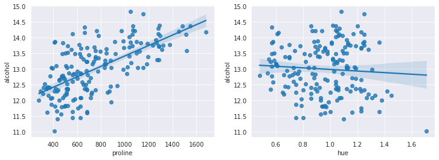

  ```python
  fig,ax = plt.subplots(1,2,figsize=(12,4))
  sns.regplot(x='proline',y='alcohol',data=df_wine,ax=ax[0])
  sns.regplot(x='hue',y='alcohol',data=df_wine,ax=ax[1]);
  ```

  What would the coefficents look like if the features were on the same scale?

# Standardizing/Normalizing Features for Gradient Descent

  $\Large z = \frac{x - \bar{x}}{s}$

[figure not shown]

  From PML

# Multiple Linear Regression with Standardization/Normalization

  - `DataFrame.apply()`: apply a function across rows (axis=0) or columns (axis=1)

  ```python
  X_zscore = df_wine[['proline','hue']].apply(lambda x: (x-x.mean())/x.std(), axis=0) # or use StandardScaler

  mlr_n = LinearRegression()
  mlr_n.fit(X_zscore, df_wine.alcohol)
  for (name,coef) in zip(X_zscore.columns,mlr_n.coef_):
      print(f'{name:10s} : {coef: 0.3f}')
  ```

  ```
  proline    :  0.568
  hue        : -0.192
  ```

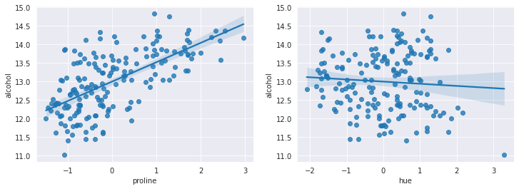

  ```python
  fig,ax = plt.subplots(1,2,figsize=(12,4))
  sns.regplot(x=X_zscore.proline,y=df_wine.alcohol,ax=ax[0]);
  sns.regplot(x=X_zscore.hue,y=df_wine.alcohol,ax=ax[1]);
  ```

# Aside: apply(axis=), rows vs columns

[figure not shown]

# Colinarity

  - MLR assumes features are linearly independent
    - eg: Can't rewrite one column as a weighted sum of the others
    - Ex: at a restaurant number, of entrees ordered will likely be linearly related to table size
  - Issue: Model won't know how to estimate $w$
    - If we add to one $w_i$ and subtract from another, there will be no change in error
  - Try to remove obvious colinearity
    - can use correlation and linear regression to detect
    - Important to consider when constructing categorical features (feature engineering)

  ```python
  df_wine.corr()
  ```

  |  | alcohol | ash | hue | proline | class |
  | --- | --- | --- | --- | --- | --- |
  | alcohol | 1.000000 | 0.211545 | -0.071747 | 0.643720 | -0.328222 |
  | ash | 0.211545 | 1.000000 | -0.074667 | 0.223626 | -0.049643 |
  | hue | -0.071747 | -0.074667 | 1.000000 | 0.236183 | -0.617369 |
  | proline | 0.643720 | 0.223626 | 0.236183 | 1.000000 | -0.633717 |
  | class | -0.328222 | -0.049643 | -0.617369 | -0.633717 | 1.000000 |

# Aside: Interpretation vs. Prediction

  - Interpretation: Explain how observed features relate to observed target
  - Prediction: Given new features, can we generate a prediction
  - Often asked to do one or the other, be clear which is most important
  - In prediction, may not worry about interpreting the model!
  - There is increased attention on interpretability

# Questions re Regression with Linear Models?

# Classification

  - **Regression** -> predict a numeric value
  - **Classification** -> predict a discrete class, category
  - **Binary classification** : two categories
    - pos/neg, cat/dog, win/lose
  - **Multiclass classification** : more than two categories/classes
    - red/green/blue, flower type, integer 0-10
  - **Multilabel classification** : can assign more than one label to an instance
    - paper topics, entities in image

# Wine as Binary Classification

  ```python
  df_wine['class'].value_counts() # originally multiclass
  ```

  ```
  1    71
  0    59
  2    48
  Name: class, dtype: int64
  ```

  ```python
  # only keep classes 0 and 1
  df_wine_2class = df_wine[df_wine['class'] < 2]

  # rename 'class' as 'target', since class is a reserved python word
  df_wine_2class = df_wine_2class.rename({'class':'target'},axis=1)

  df_wine_2class.target.value_counts()
  ```

  ```
  1    71
  0    59
  Name: target, dtype: int64
  ```

# Classifying Wine with a Linear Model

  - Can't use our linear regression model directly

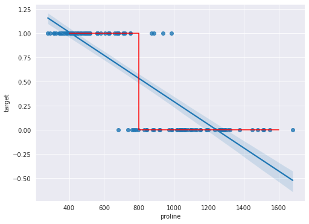

  ```python
  fig,ax = plt.subplots(1,1,figsize=(8,6))
  sns.regplot(x=df_wine_2class.proline,y=df_wine_2class.target);
  ax.plot([400,800,800,1600],[1,1,0,0],c='r');
  ```

  - Want something with that looks like a threshold
  - Would like a prediction between 0 and 1

# Logistic Regression

  $\Large logistic(x) = \frac{1}{1+e^{(-x)}}$

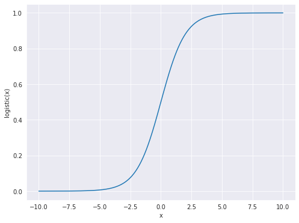

  ```python
  def logistic(x,w1=1,w0=0):
      return 1 / (1+np.exp(-(w0+w1*x)))

  x = np.linspace(-10,10,1000) # generate 1000 numbers evenly spaced between -10 and 10
  fig,ax = plt.subplots(1,1,figsize=(8,6))
  ax.plot(x,logistic(x));
  ax.set_xlabel('x');ax.set_ylabel('logistic(x)');
  ```

# Logistic Regression with sklearn

  - Our problem becomes: $P(y_i=1|x_i) = logistic(w_0 + w_1 x_i)+\varepsilon_i$

  ```python
  from sklearn.linear_model import LogisticRegression

  X = df_wine_2class.proline.values.reshape(-1,1)
  y = df_wine_2class.target

  logr = LogisticRegression(fit_intercept=True).fit(X,y)
  print(f'w_0 = {logr.intercept_[0]:0.2f}')
  print(f'w_1 = {logr.coef_[0][0]:0.2f}')
  ```

  ```
  w_0 = 11.97
  w_1 = -0.01
  ```

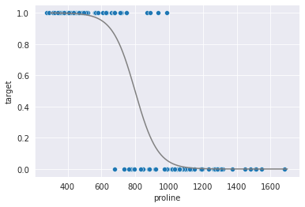

  ```python
  fig,ax = plt.subplots(1,1,figsize=(6,4))
  x = np.linspace(300,1700,1000)
  logistic_x = logistic(x,logr.coef_[0],logr.intercept_)
  ax.plot(x,logistic_x,c='gray');
  sns.scatterplot(x=df_wine_2class.proline,y=df_wine_2class.target, ax=ax);
  ```

# Adding the Threshold

  - Can treat the output of the logistic function as $P(y=1|x)$
  - Threshold at .5 (50%) to get class prediction

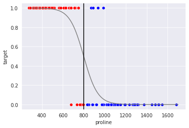

  ```python
  threshold = x[np.argmin(np.abs(logistic_x - .5))]

  predicted_0 = df_wine_2class[df_wine_2class.proline <= threshold]
  predicted_1 = df_wine_2class[df_wine_2class.proline > threshold]

  fig,ax = plt.subplots(1,1,figsize=(6,4))
  sns.scatterplot(x='proline',y='target', data=predicted_0, color='r',ax=ax);
  sns.scatterplot(x='proline',y='target', data=predicted_1, color='b',ax=ax);
  ax.plot(x,logistic_x,c='gray');
  ax.axvline(threshold,c='k');
  ```

# Getting Predictions from sklearn

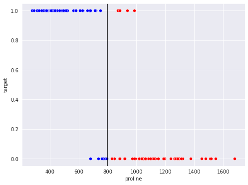

  ```python
  yhat = logr.predict(X)

  predicted_0 = df_wine_2class[yhat==0]
  predicted_1 = df_wine_2class[yhat==1]

  fig,ax = plt.subplots(1,1,figsize=(8,6))
  sns.scatterplot(x='proline',y='target', data=predicted_0, color='r',ax=ax);
  sns.scatterplot(x='proline',y='target', data=predicted_1, color='b',ax=ax);
  ax.axvline(threshold,c='k');
  ```

  Note we have some errors!

# Getting Probabilities from sklearn

  - said we could use output of logistic as $P(y=1|x)$

  ```python
  p_y = logr.predict_proba(X)
  p_y[:5] # p(y=0|x), p(y=1|x)
  ```

  ```
  array([[9.81833759e-01, 1.81662409e-02],
         [9.77356984e-01, 2.26430157e-02],
         [9.96947414e-01, 3.05258552e-03],
         [9.99963234e-01, 3.67664871e-05],
         [2.77482032e-01, 7.22517968e-01]])
  ```

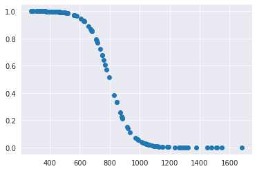

  ```python
  plt.scatter(df_wine_2class.proline,p_y[:,1]);
  ```

# Interpreting Logistic Regression Coefficients

  - After some math

  $\log\left(\frac{y_i}{1-y_i}\right) = w_0 + w_1 x_{i1}$
  - this is the **log odds ratio** of p(y=1)/p(y=0)
  - odds range from 0 to positive infinity
  - odds(5) -> 5/1 -> 5 out of 6 times -> .83
  - odds(.2) -> 1/5 -> 1 out of 6 times -> .16

  See [here](https://stats.idre.ucla.edu/other/mult-pkg/faq/general/faq-how-do-i-interpret-odds-ratios-in-logistic-regression/) for a good explanation

# Logistic Regression with Multiple Features

  ```python
  X = df_wine_2class[['proline','hue']]
  X_zscore = X.apply(lambda x: (x-x.mean())/x.std())

  logrm = LogisticRegression().fit(X_zscore,y)
  for (name,coef) in zip(X.columns,logrm.coef_[0]):
      print(f'{name:10s} : {coef: 0.3f}')
  ```

  ```
  proline    : -3.464
  hue        :  0.488
  ```

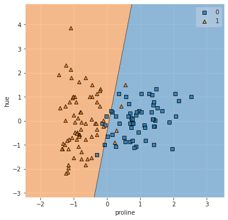

  ```python
  # need to have run: conda install -n eods-f20 -c conda-forge mlxtend
  from mlxtend.plotting import plot_decision_regions

  fig,ax = plt.subplots(1,1,figsize=(6,6))
  plot_decision_regions(X_zscore.values, y.values, clf=logrm, ax=ax);
  ax.set_xlabel(X.columns[0]); ax.set_ylabel(X.columns[1]);
  ```

# Linearly Seperable Data

  - Logistic Regression depends on data being linearly seperable

[figure not shown]

  From PML

# Which boundary to choose? Support Vector Machines (SVMs)

  - For a linearly seperable dataset, where should we place the decision boundary?
  - Support Vector Machine (SVM) tries to "maximize the margin" between classes

[figure not shown]

  From PML

# SVM Hyperparameter C

  - **Hyperparameter**: Something we set

[figure not shown]

  From PML

# SVM with sklearn

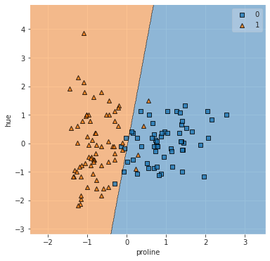

  ```python
  from sklearn.svm import SVC
  svm_linear = SVC(kernel='linear')
  svm_linear.fit(X_zscore,y);

  fig,ax = plt.subplots(1,1,figsize=(6,6))
  plot_decision_regions(X_zscore.values, y.values, clf=svm_linear);
  plt.xlabel(X.columns[0]); plt.ylabel(X.columns[1]);
  ```

# Non-Linear Boundaries with SVMs Kernel Trick

  - **Kernel Trick**: Map data to a higher dimensional space and find linear boundary there

[figure not shown]

  From PML

# SVM Kernel Trick with RBF Kernel

  - RBF (Radial-Basis Function) kernel

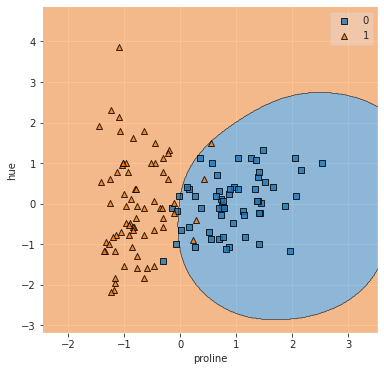

  ```python
  svm_rbf = SVC(kernel='rbf')
  svm_rbf.fit(X_zscore,y);

  fig,ax = plt.subplots(1,1,figsize=(6,6))
  plot_decision_regions(X_zscore.values, y.values, clf=svm_rbf);
  plt.xlabel(X.columns[0]); plt.ylabel(X.columns[1]);
  ```

# If we have time...

# From Perceptron to Artificial Neural Network

[figure not shown]

  From PML

# Perceptron: Early Neuron Model

[figure not shown]

  From PML

# Perceptron in sklearn

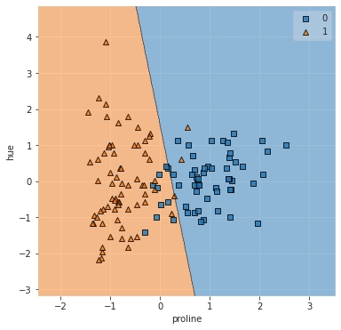

  ```python
  from sklearn.linear_model import Perceptron
  perceptron = Perceptron()
  perceptron.fit(X_zscore,y);

  fig,ax = plt.subplots(1,1,figsize=(6,6))
  plot_decision_regions(X_zscore.values, y.values, clf=perceptron);
  plt.xlabel(X.columns[0]); plt.ylabel(X.columns[1]);
  ```

# Perceptron to Adaline

[figure not shown]

  From PML

# Adaline to Logistic Regression

[figure not shown]

  From PML

# Components of Single Layer Neural Net

[figure not shown]

  From PML

# Multi-Layer Neural Network

[figure not shown]

  From PML

# Complex Optimization Space

[figure not shown]

  From PML

# Activation Functions

[figure not shown]

  From PML

# Multi-Layer Perceptron with sklearn

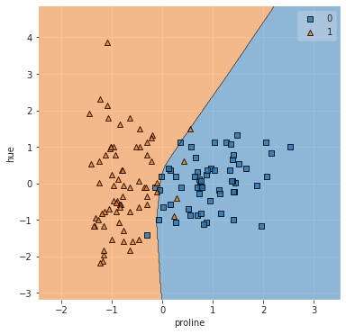

  ```python
  from sklearn.neural_network import MLPClassifier, MLPRegressor
  mlp = MLPClassifier(hidden_layer_sizes=(100,),
                      max_iter=1000)
  mlp.fit(X_zscore,y);

  fig,ax = plt.subplots(1,1,figsize=(6,6))
  plot_decision_regions(X_zscore.values, y.values, clf=mlp);
  plt.xlabel(X.columns[0]); plt.ylabel(X.columns[1]);
  ```

# Questions re Classification with Linear Models?